# Local Estimation of Riemannian Metric

Jiaming Qiu

2022-06-12

A toy example for using the package. We consider the Poincare ball model for hyperbolic space.

```r
library(foreach)
# library(remeloc)
devtools::load_all()
```

```
#> i Loading remeloc
```

```r
library(tidyverse)
d <- 2
manifold <- spaceHyperbolic(d, model = 'ball', r = 2)
coef.shrink <- 0.75 # to avoid being too close to "boundary"
local.reach <- 0.2
```

Generating data and graph, then plot some of the edges.

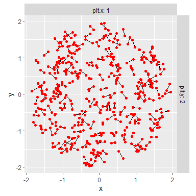

```r
set.seed(1)
obsv.coord <- manifold$genPnt(10^5)
idx.edge <- genGraph(10^6, obsv.coord, local.reach = local.reach, exact = F)
plt.dat <- plotGraph(obsv.coord, idx.edge, max.n.edge = 250) +
  coord_fixed(ratio = 1)
plt.dat
```

Then we construct response by adding 10% of noise to the squared distance. In the data frame, one row for one edge, where the last two columns are index of nodes correspond to this edge.

```r
# squared distance
dat <- tibble(sqdist = manifold$dist(
  obsv.coord[idx.edge[, 1], ], obsv.coord[idx.edge[, 2], ]
) ^ 2)
dat <- dat %>% mutate(
  noise = rnorm(length(sqdist), 0, sqrt(sqdist * 0.1)),
  y = pmax(0, sqdist + noise)
) %>% bind_cols(idx.edge %>% as.data.frame)
names(dat) <- c('sqdist', 'noise', 'y', sprintf('p%s', seq(2)))
dat %>% head
```

```
#> # A tibble: 6 x 5
#>    sqdist  noise     y    p1    p2
#>     <dbl>  <dbl> <dbl> <int> <int>
#> 1 10.1    -0.525 9.61      3    81
#> 2  0.0643  0.166 0.230     3  1609
#> 3  4.49    0.350 4.84      3  2175
#> 4  9.87   -1.93  7.93      3  3964
#> 5  1.25    0.458 1.70      3  4302
#> 6  3.30   -0.436 2.87      3  4629
```

Next, “fit” a model, namely specify local regression structures. Here we specify that response “y” should be tied to nodes indexed by columns “p1” and “p2”, coordinates of those nodes are supplied as well. Further, we require the algorithm to use no more than $10^4$ edges locally.

```r
fit <- fitMetric(
  y ~ p1 : p2,
  data = dat, coord = obsv.coord,
  optns = list(n.local = 10^4, local.reach = 0.2)
)
```

Then we estimate metric tensor at targeted points using the model. This could take a while. Estimation here is done on a $128 \times 128$ grid.

```r
target <- manifold$genGrid(128) * coef.shrink
# parallel estimation
system.time({
  N.CORES <- 10
  doParallel::registerDoParallel(cores = N.CORES)
  st.time <- proc.time()
  esti.metric <- foreach(
    w.target = split.data.frame(
      target, # %>% head(2 * N.CORES),
      cut(seq(nrow(target)), N.CORES)
    ),
    # .export = 'fit',
    .packages = 'remeloc', .errorhandling = 'pass'
  ) %dopar% {
    estiMetric(w.target, fit)
  }
  doParallel::stopImplicitCluster()
})
```

```
#>    user  system elapsed
#>    0.34    0.14   55.19
```

```r
if(!any(sapply(esti.metric, inherits, what = 'error'))){
  esti.metric <- unlist(esti.metric, recursive = F)
}else{
  stop('Error in parallel resluts.')
}
```

Now we can inspect the estimated Riemannian metric tensor. First, inspect the component functions.

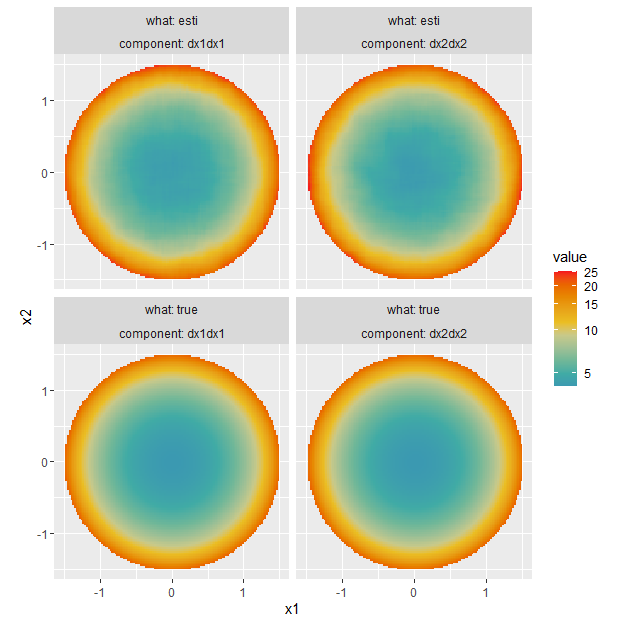

```r
df.esti.metric <- getMetricDF(target, esti.metric)
df.true.metric <- getMetricDF(target, manifold$metric)
map.esti <- df.esti.metric %>% mutate(what = 'esti') %>%
  bind_rows(df.true.metric %>% mutate(what = 'true')) %>%
  bind_rows(
    left_join(df.true.metric %>% rename('true' = 'value'), df.esti.metric) %>%
      mutate(value = true - value, what = 'err') %>% select(-all_of('true'))
  ) %>%
  filter(component != 'dx1dx2', what != 'err') %>%
  # filter(what == 'err') %>%
  ggplot() +
  geom_raster(aes(x = x1, y = x2, fill = value)) +
  scale_fill_gradientn(
    colors = hcl.colors(10, 'Zissou 1'),
    trans = scales::pseudo_log_trans(base = 10)
  ) +
  facet_wrap(what ~ component, labeller = label_both) +
  coord_fixed(ratio = 1)
map.esti
```

We can also look at equal geodesic ellipses. The following ellipses are plotting $\{x: (x - p)^T G(p) (x - p) = c\}$ for given center point $p$ and metric tensor matrix $G(p)$. The constant $c$ is the prespecified geodesic distance to travel.

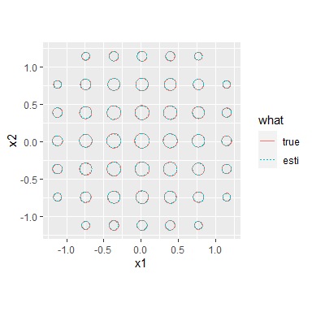

```r
colnames(target) <- c('x1', 'x2')
df.ell <- getMetricEllipsoid(target, esti.metric, radius = 0.2, tissot = T) %>%
  mutate(what = 'esti') %>% bind_rows(getMetricEllipsoid(
    target, apply(target, 1, manifold$metric, simplify = F), radius = 0.2
  ) %>% mutate(what = 'true')) %>%
  mutate(what = factor(what, levels = c('true', 'esti')))
# index the row and column of points
idx.xy <- apply(target, 2, function(x) match(x, sort(unique(x))))
idx.xy <- as.data.frame(idx.xy) %>% mutate(idx.pnt = row_number()) %>%
  setNames(c('idx.x', 'idx.y', 'idx.pnt')) %>% as_tibble
df.ell <- df.ell %>% left_join(idx.xy, by = 'idx.pnt') %>% as_tibble

map.ell <- df.ell %>%
  filter(idx.x %% 16 == 0, idx.y %% 16 == 0) %>%
  ggplot() +
  geom_path(aes(
    x = x1, y = x2, linetype = what, color = what,
    group = interaction(idx.pnt, what)
  )) +
  coord_fixed(ratio = 1)
map.ell
```

Next, consider the geodesic curve. However, the current estimated metric cannot be used for numeric differential so as to obtain Christoffel symbol, as it is almost locally constant. This means one cannot plug the “estiMetric” directly into “getGeodesic” function, but must use the christ argument, which can be rather slow; or to use additional post-smoothing, at a cost of accuracy. Currently the “approxfunMetric” uses local polynomial to provide a smoothed estimated tensor. However, it is not interpolation, be careful when using it.

```r
suppressWarnings({approx.metric <- approxfunMetric(
  target, esti.metric, bw = 5 * max(abs(target[1, ] - target[2, ])),
  optns = list(maxk = 1000)
)})
geo.f.true <- getGeodesic(manifold$metric, d = d)
geo.f.esti <- getGeodesic(christ = function(x){estiMetric(x, fit, optns = list(
  local.reach = 0.25, deriv = 1
))$christ[[1]]}, d = d)
geo.f.approx <- getGeodesic(approx.metric, d = d)
system.time({df.geo <- bind_rows(
  geo.f.true(rep(0.75, d), c(-1, 0)) %>% as.data.frame %>% as_tibble %>%
    mutate(what = 'true'),
  geo.f.esti(rep(0.75, d), c(-1, 0), rtol = 1e-4) %>% #200s if rtol = 1e-6
    as.data.frame %>% as_tibble %>% mutate(what = 'estimated'),
  geo.f.approx(rep(0.75, d), c(-1, 0)) %>% as.data.frame %>% as_tibble %>%
    mutate(what = 'post-smoothing')
)})
```

```
#>    user  system elapsed
#>   35.52    1.04   36.82
```

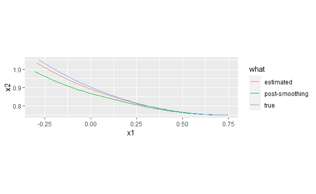

```r
df.geo %>% ggplot() +
  geom_path(aes(x = x1, y = x2, color = what)) +
  coord_fixed()
```